# Probability and simulation

POLI 210 · Seminar 2

Brad LeVeck

2026-09-09

## Today’s questions

- What are the possible outcomes of a random process?
- Which outcomes count as the event we care about?
- When can we calculate a probability by counting?
- How can R simulate the same process?

**Reading:** PSD §§2.1, 2.2, and 2.4. Conditional probability and Bayes’ rule are for next week.

## Why political scientists use probability

**Polling:** Even with a fixed population, different samples give different results.

**Experiments:** A random assignment procedure determines who receives treatment.

**Our task today:** Describe the procedure, then ask how often an event occurs.

The political examples use hypothetical numbers, not current polling estimates.

## The language of a probability model

| Term | Meaning | Two coin tosses |
| --- | --- | --- |
| Random experiment | Procedure with an uncertain outcome | Toss twice |
| Outcome | One complete result | $HT$ |
| Sample space $S$ | Set of all possible outcomes | $\{HH,HT,TH,TT\}$ |
| Event $E$ | A subset of $S$ | Exactly one head: $\{HT,TH\}$ |

A **trial** is one repetition of the entire experiment. Random does **not** automatically mean equally likely.

## Describe outcomes before assigning probabilities

Two independent fair tosses give four equally likely ordered outcomes:

$$S=\{HH,HT,TH,TT\}.$$

But the possible **counts** of heads are not equally likely:

| Heads | Outcomes | Probability |
| --- | --- | --- |
| 0 | $TT$ | $1/4$ |
| 1 | $HT,TH$ | $1/2$ |
| 2 | $HH$ | $1/4$ |

The representation of an outcome matters.

## Events are sets

| Notation | Read it as | In R, for logical vectors `E`, `F` |
| --- | --- | --- |
| $E\cap F$ | Both $E$ and $F$ | `E & F` |
| $E\cup F$ | $E$ or $F$, including both | `E` \| `F` |
| $\overline E$ | Not $E$ | `!E` |
| $\emptyset$ | Impossible event | No outcomes |
| $E\subseteq F$ | Every outcome in $E$ is in $F$ | $E$ implies $F$ |

**Disjoint events:** $E\cap F=\emptyset$. They cannot both occur in one trial.

## What makes a probability assignment valid?

1. $P(E)\geq 0$ for every event $E$.
2. $P(S)=1$.
3. Probabilities add for disjoint events: $P(E\cup F)=P(E)+P(F)$ when $E\cap F=\emptyset$.

The third rule extends to any countable collection of pairwise disjoint events.

We can distribute probability unevenly across outcomes. The total must still be 1.

## Three useful consequences

**Complement**
$$P(\overline E)=1-P(E).$$

**Union**
$$P(E\cup F)=P(E)+P(F)-P(E\cap F).$$

**Containment:** If $E\subseteq F$, then $P(E)\leq P(F)$.

Why do we subtract the intersection in the union rule?

## A voting example: organize the overlap

In a hypothetical population, let:

- $E$: plans to vote in the presidential election, $P(E)=0.55$;
- $F$: plans to vote in the congressional election, $P(F)=0.36$;
- $P(E\cap F)=0.35$.

**With a neighbor:** Find the probability of planning to vote in at least one election, in neither, and in exactly one.

Start by splitting $S$ into four disjoint pieces.

## Four disjoint pieces make the calculation clear

| Piece of the sample space | Probability |
| --- | --- |
| Both elections | $0.35$ |
| Presidential only | $0.55-0.35=0.20$ |
| Congressional only | $0.36-0.35=0.01$ |
| Neither | $1-(0.35+0.20+0.01)=0.44$ |

At least one: $0.56$. Exactly one: $0.21$.

Check: the four disjoint pieces sum to 1.

## When counting gives a probability

If $S$ is finite and its outcomes are **equally likely**,

$$P(E)=\frac{|E|}{|S|}.$$

Two independently rolled fair dice have $6\times6=36$ equally likely ordered pairs.

Their sums run from 2 through 12, but those 11 sums are **not** equally likely.

**Checkpoint:** Would `sample(2:12, 1)` simulate the sum correctly?

## Enumerate a sample space in R

```r
S <- expand.grid(first = 1:6, second = 1:6)
head(S, 4)
```

```
  first second
1     1      1
2     2      1
3     3      1
4     4      1
```

```r
nrow(S)
```

```
[1] 36
```

Each row is one complete outcome. This table is the full sample space, not a random sample from it.

## Select an event, then count it

```r
E <- (S$first + S$second) == 7
sum(E)                 # number of favorable outcomes
```

```
[1] 6
```

```r
mean(E)                # favorable / total
```

```
[1] 0.1666667
```

In R, `TRUE` acts like 1 and `FALSE` like 0 in these calculations.

This mean is an **exact probability** because the table contains every equally likely outcome once.

## sample() generates random draws

```r
set.seed(210)
sample(1:6, size = 12, replace = TRUE)
```

```
 [1] 4 3 1 1 6 3 1 4 1 2 6 5
```

- `x`: the values to draw from (here `1:6`).
- `size`: how many draws to return.
- `replace`: can the same entry be drawn again?
- `prob`: optional relative probabilities; the default is uniform.

`set.seed()` makes a simulation reproducible; it does not make a model correct.

## Replacement is a modeling choice

```r
sample(1:6, size = 2, replace = TRUE)   # two die rolls
sample(1:6, size = 2, replace = FALSE)  # two distinct slips
```

Dice may show the same number twice. Two distinct slips cannot be the same slip.

**Important:** One trial can contain multiple draws. To simulate two dice, one trial must return two rolls—not one roll and not all 36 possible pairs.

## A general simulation recipe

1. Describe one trial precisely.
2. Generate its complete outcome.
3. Record whether the event occurred: 1 or 0.
4. Repeat the trial many times.
5. Average those indicators.

$$\widehat p_N=\frac{1}{N}\sum_{i=1}^N I_i,
\qquad I_i=\begin{cases}1&\text{event occurs in trial }i,\\0&\text{otherwise.}\end{cases}$$

The result estimates the probability **under the model we simulated**.

## Simulate the two-dice event

```r
set.seed(211)
N <- 20000
first <- sample(1:6, N, replace = TRUE)
second <- sample(1:6, N, replace = TRUE)
hit <- (first + second) == 7
c(estimate = mean(hit), exact = 6 / 36)
```

```
 estimate     exact
0.1646000 0.1666667
```

Entry `i` in each vector belongs to trial `i`.

The Monte Carlo estimate usually differs slightly from the exact probability.

## More trials stabilize the estimate

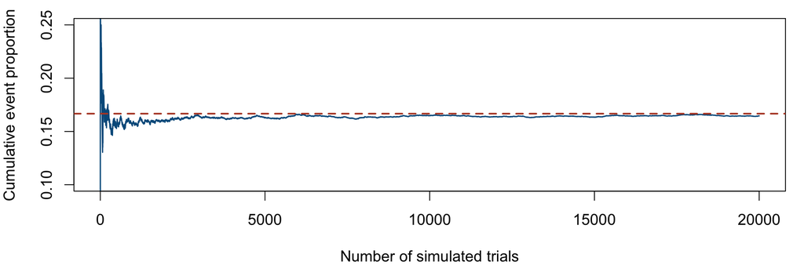

The dashed line is the exact probability, $1/6$. The law of large numbers supports stabilization for independent repeated trials from the same model. Accuracy need not improve at every step.

## A randomized experiment: define one assignment

Three participants are each assigned treatment by an independent fair coin.

```r
set.seed(212)
assignment <- sample(c("C", "T"), 3, replace = TRUE)
assignment
```

```
[1] "T" "T" "C"
```

```r
any(assignment == "T") & any(assignment == "C")
```

```
[1] TRUE
```

Our event: **both treatment and control are represented**.

This is a question about the assignment procedure, before observing any outcomes.

## The experiment’s sample space

$$S=\{CCC,CCT,CTC,CTT,TCC,TCT,TTC,TTT\}.$$

With independent fair assignments, each pattern has probability $1/8$.

Six patterns include both groups:

$$P(\text{both groups represented})=\frac{6}{8}=\frac34.$$

**Design question:** Does this procedure guarantee a usable comparison group?

## replicate() repeats the whole trial

```r
set.seed(213)
mixed <- replicate(20000, {
  a <- sample(c("C", "T"), 3, replace = TRUE)
  any(a == "T") & any(a == "C")
})
mean(mixed)
```

```
[1] 0.74855
```

The last expression inside `{ ... }` is the result saved from each trial.

Put `set.seed()` **before** `replicate()`, not inside it.

## A different design has a different sample space

Suppose we require exactly one treated participant:

```r
sample(c("T", "C", "C"), size = 3, replace = FALSE)
```

```
[1] "C" "C" "T"
```

Now $S=\{TCC,CTC,CCT\}$. Each pattern has probability $1/3$.

Both groups are represented with probability 1.

We changed the assignment procedure—not just the R syntax.

## A hypothetical polling model

Assume each sampled response is an independent approval indicator with $P(\text{approve})=0.60$.

```r
set.seed(214)
responses <- sample(c(0, 1), 20, replace = TRUE,
                    prob = c(0.40, 0.60))
mean(responses)
```

```
[1] 0.5
```

`1` means approve. The sample mean is the approval share.

For a large population, this is a simplified model of repeated sampling.

## Weighted outcomes: calculate and simulate

For two independent responses with approval probability 0.60, the ordered outcomes are **not** equally likely:

| Outcome | Probability under independent sampling |
| --- | --- |
| Neither approves: $00$ | $0.40\times0.40=0.16$ |
| First only: $10$ | $0.60\times0.40=0.24$ |
| Second only: $01$ | $0.40\times0.60=0.24$ |
| Both approve: $11$ | $0.60\times0.60=0.36$ |

Agreement is $\{00,11\}$, so $P(\text{agree})=0.16+0.36=0.52$. Multiply within an independent pair; add across disjoint matching outcomes.

## Repeat the poll, not just one response

What is the chance that a poll of 100 reports **less than 50% approval**?

```r
set.seed(215)
poll_share <- replicate(10000, {
  x <- sample(c(0, 1), 100, replace = TRUE,
              prob = c(0.40, 0.60))
  mean(x)
})
mean(poll_share < 0.50)
```

```
[1] 0.0168
```

There are 100 responses per trial and 10,000 trials.

## Different polls, one assumed population

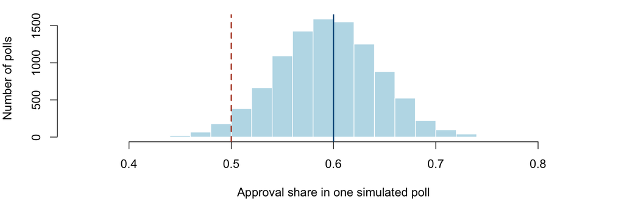

Dashed line: 0.50; solid line: the assumed 0.60 approval rate. This captures sampling variability under our assumptions. It does not fix nonresponse, question wording, or an unrepresentative sampling process.

## Counting without listing every outcome

**Product rule:** If one choice has $m$ options and the next has $n$ options for each first choice, there are $mn$ ordered possibilities.

- Two dice: $6\times6=36$ ordered outcomes.
- Twenty yes/no responses: $2^{20}=1{,}048{,}576$ response sequences.
- Three distinct names chosen in order from six: $6\times5\times4=120$.

Counting outcomes does not, by itself, tell us they are equally likely. The polling sequences are not equally likely when approval probability is 0.60.

## Order and replacement determine the count

| Procedure | Number of possibilities |
| --- | --- |
| Ordered, $k$ draws from $n$, with replacement | $n^k$ |
| Ordered, $k$ distinct choices from $n$ | $n!/(n-k)!$ |
| Unordered, $k$ distinct choices from $n$ | $\binom nk=n!/[k!(n-k)!]$ |

For choices without replacement, $0\leq k\leq n$; also $0!=1$.

Use `factorial(n)` and `choose(n, k)` in R.

**Check:** Are a committee and a ranked list the same kind of outcome?

## A committee example

Choose a two-person committee uniformly from six legislators: four incumbents and two newcomers.

$$P(\text{both incumbents})=\frac{\binom42}{\binom62}=\frac6{15}=0.40.$$

```r
choose(4, 2) / choose(6, 2)
```

```
[1] 0.4
```

The committee is unordered. Every pair of distinct legislators is equally likely.

## Simulate the same committee procedure

```r
set.seed(216)
both_incumbents <- replicate(20000, {
  committee <- sample(1:6, 2, replace = FALSE)
  all(committee <= 4)  # legislators 1–4 are incumbents
})
mean(both_incumbents)
```

```
[1] 0.3978
```

**Your turn:** Find the probability of exactly one newcomer by counting. Then change the final expression to simulate that event.

## Before trusting a simulation

- Does one trial represent the intended process?
- Did we choose the right replacement rule and weights?
- Is the event coded correctly, including equality and boundary cases?
- Are all repetitions generated afresh?
- Is the answer plausible, and does it agree with an exact calculation when available?

Running an incorrect model more times produces a more stable wrong answer.

## A2: calculation and simulation

**Due:** Wednesday, September 16, at 1:30 p.m.

PSD exercises **2.1, 2.3, 2.4, 2.7, 2.9, 2.33, and 2.36**.

- Read each linked exercise; write explanations in the Quarto report.
- Save code in `R/a2_answers.R`; run the visible checks locally.
- Render, commit, push, and check GitHub Actions.

Next week: conditional probability, independence, and Bayes’ rule; Blitzstein and Hwang, Chapter 2.

## Sources and scope

Speegle and Clair, [*Probability, Statistics, and Data*, Chapter 2](https://probstatsdata.com/probchapter.html), especially §§2.1, 2.2, and 2.4.

The voting example adapts prior POLI 210 probability materials. Polling and three-person random-assignment examples build on themes in Matthew Blackwell’s *Gov 2000: Random Variables* (Fall 2016), retained in the earlier course archive.

The simulations and numerical polling assumptions here are instructional examples. Formal random-variable distributions and inference come later in the course.